```python
from scipy import signal
from scipy import ndimage
import matplotlib.pyplot as plt
import numpy as np
import os
from scipy import misc
from sklearn.cluster import KMeans
import seaborn as sns
from numpy import linalg as la
from math import floor
from ipywidgets import interact, interactive, fixed, interact_manual
from ipywidgets import FloatSlider
from ipywidgets import IntSlider
plt.rcParams['figure.figsize'] = (10, 10)
from mpl_toolkits import mplot3d
```

[Página principal](https://jeroaranda.github.io)

Por [Jerónimo Aranda](https://twitter.com/jeroaranda).

# Ver y pensar

## Introducción

Los humanos procesamos información visual de formas casi milagrosas y en tiempo real.

- Ajustamos contraste
- Ajustamos brillo
- Leémos
- Reconocemos objetos y caras.

**¿Qué resolución ve el ojo humano?**

Dejando por un lado la explicación neurológica, intentemos acercarnos a la comprensión de la visión desde el procesamiento de información.

## Definiciones

Para acercarnos como buenos matemáticos a experiencias visuales, es necesario conceptualizar y abstraer de mejor forma estos objetos. Comencemos con definir $img(x,y)$ como una imagen en blanco y negro.

Sea $A =[0,m]$ x $[0,n] \in \mathbb{R}^2$, definamos una imagen como una función $img(x,y)$ de la siguiente forma :

$$img\colon \begin{array}{>{\displaystyle}l} A \rightarrow \mathbb{R} \\ (x,y)\mapsto img(x,y) \in [0,1] \end{array} $$

Es decir a cada una de las posiciones $(x,y)$ le corresponderá un tono de la escala de grises que se encuentra abajo.

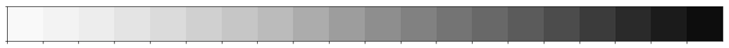

```python
sns_plot=sns.palplot(sns.color_palette("Greys",20))
```

Esta correspondencia pudiera darse con cualquier otra paleta de colores.

## Ejemplo de imagen en blanco y negro

Dada la naturaleza continua de nuestro lienzo $A$, podemos suponer las posibles problemáticas que se presentan cuando una computadora intenta procesar una imagen. Para esto discretizaremos nuestra imagen con una nueva definición:

Nuestro imagen $img$ será una matriz real de $m*n$ en la que a cada una de sus entradas le corresponderá un valor entre cero y uno, es decir:

$$img(i,j)\in [0,1] $$

Por ejemplo, supongamos $m,n=50$ y elijamos valores aleatorios para cada $img(i,j)$:

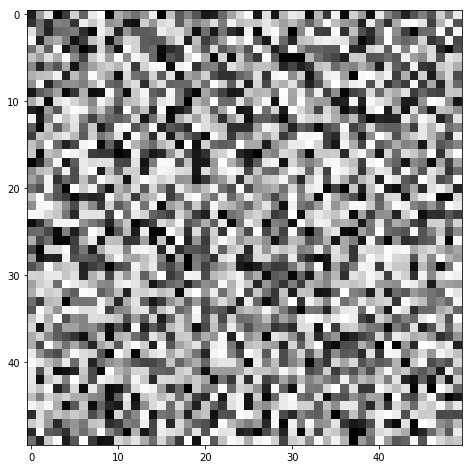

```python
img=np.random.random((50,50))
ax=plt.imshow(img,cmap='Greys')
```

Veamos la misma imagen codificada con una paleta distinta:

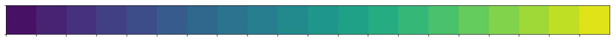

```python
sns_plot=sns.palplot(sns.color_palette("viridis",20))
```

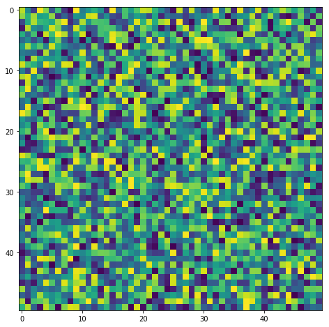

```python
ax=plt.imshow(img,cmap='viridis')
```

## Imágenes a color

Para extender la noción de imagen en blanco y negro a una a color, necesitamos extender nuestra matriz de $m*n$ a un tensor, o arreglo multidimensional con dimensiones $m*n*3$, en la que cada nivel de la 3era dimensión determina cada uno de los canales rojo, verde y azul.

$$img(i,j) = (r,g,b)$$

donde $r,g,b \in [0,1]$

```python
def f(R,G,B):
    sns.palplot([R,G,B])
    return (R,G,B)
interact(f, R=FloatSlider(min=0, max=1, step=.05, value=.6,continuous_update=False),G=FloatSlider(min=0, max=1, step=.05, value=0.1,continuous_update=False),B=FloatSlider(min=0, max=1, step=.05, value=.4,continuous_update=False));
```

- $(0,0,0)$ es negro.
- $(1,1,1)$ es blanco.
- cada $e_i$ corresponde a uno de los colores rojo, verde y azul.

Es importante mencionar que existen muchos otras abstracciones del color como [CMYK](https://en.wikipedia.org/wiki/CMYK_color_model),[HSV and HSL](https://en.wikipedia.org/wiki/HSL_and_HSV), [CIELAB](https://en.wikipedia.org/wiki/CIELAB_color_space).

## Ejemplo imagen a color

```python
plt.rcParams['figure.figsize'] = (20, 10)
```

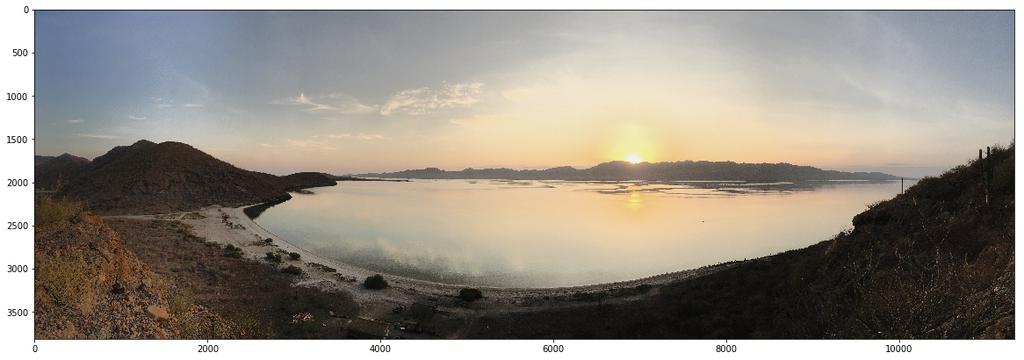

```python
img=misc.imread('../../../../Scripts/E1D73264-0143-42C7-B511-562343FB6D27.jpg')
ax=plt.imshow(img)
```

```python
img[0,0,:]
```

```
array([ 0,  9, 40], dtype=uint8)
```

```python
plt.rcParams['figure.figsize'] = (10,8)
```

### Canales R,G y B.

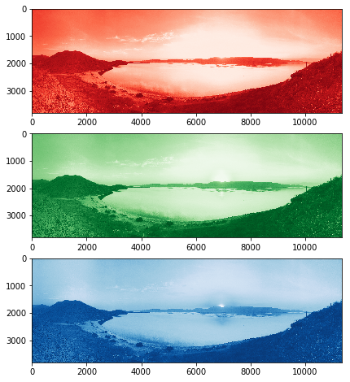

```python
fig, axs = plt.subplots(3)
axs[0].imshow(img[:,:,0],cmap='Reds_r')
axs[1].imshow(img[:,:,1],cmap='Greens_r')
axs[2].imshow(img[:,:,2],cmap='Blues_r')
plt.show()
```

## Derivada de una imagen

Recordando la primera definición.

Sea $A =[0,m]$ x $[0,n] \in \mathbb{R}^2$, definamos una imagen como una función $img(x,y)$ de la siguiente forma :

$$img\colon \begin{array}{>{\displaystyle}l} A \rightarrow \mathbb{R} \\ (x,y)\mapsto img(x,y) \in [0,1] \end{array} $$

Parece plantear inmediatamente la posibilidad de derivar. Esto está implementado por un filtro Sobel.

## Filtro Sobel

Sea $img$ nuestra imagen, ($*$) la operación convolución entonces $G_x, G_y$ aproximan el gradiente en cada dirección:

$$\mathbf{G_x} = \begin{bmatrix} -1 & 0 & +1 \\ -2 & 0 & +2 \\ -1 & 0 & +1 \end{bmatrix} * img \quad \mbox{y} \quad \mathbf{G_y} = \begin{bmatrix} -1 & -2 & -1 \\ 0 & 0 & 0 \\ +1 & +2 & +1 \end{bmatrix} * img $$

Y $G$ aproximará la magnitud del gradiente: $$\mathbf{G} = \sqrt{ \mathbf{G_x}^2 + \mathbf{G_y}^2 }$$

### Leamos una imagen en blanco y negro.

```python
plt.rcParams['figure.figsize'] = (8,8)
```

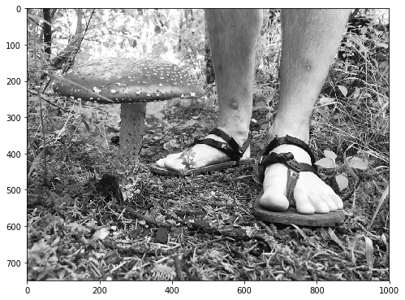

```python
import imageio
img = imageio.imread('../../../../Scripts/C712DD03-E345-459E-928F-A9949A247E75-1000.jpg', as_gray=True)
ax=plt.imshow(img,cmap='Greys_r')
```

```python
img[0,0]
```

```
99.788
```

### Derivemos aplicando el filtro sobel

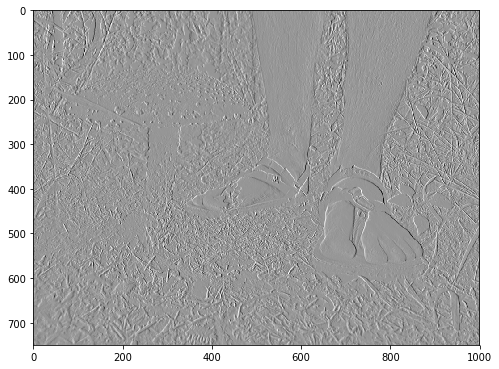

```python
from scipy import ndimage, misc
derivada=ndimage.sobel(img)
plt.imshow(derivada,cmap='Greys_r')
```

# Formas de codificar información en visualizaciones:

[figure not shown]

## Ejemplos de paletas de color

Paleta secuenciales:

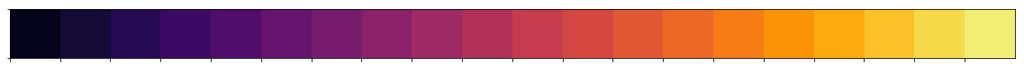

```python
sns_plot=sns.palplot(sns.color_palette("inferno",20))
```

Paleta divergente:

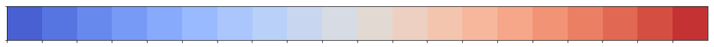

```python
sns_plot=sns.palplot(sns.color_palette("coolwarm",20))
```

Paleta categorica:

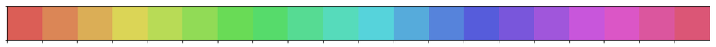

```python
sns.palplot(sns.color_palette("hls", 20))
```

# Conclusiones

- El procesamiento de información visual se basa en conceptos matemáticos de campos diversos.
- Python presenta herramientas bastante accesibles para comenzar a trabajar estos conceptos.
- Las buenas visualizaciones permiten transformar conceptos abstractos o grandes cantidades de datos en información accesible al cerebro a 10 millones de bits por segundo.

# Gracias

[Página principal](https://jeroaranda.github.io)

Por [Jerónimo Aranda](https://twitter.com/jeroaranda).